# FF

- Hipertension:

```python
from collections import Counter
Z= Counter(New['Hipertension'])
print(Z)
```

```
Counter({0: 88726, 1: 21801})
```

```python
Z1=21801
Z2=88726
print("The number of people with Hipertension is",Z1)
print("The number of people without Hipertension is",Z2)
```

```
The number of people with Hipertension is 21801
The number of people without Hipertension is 88726
```

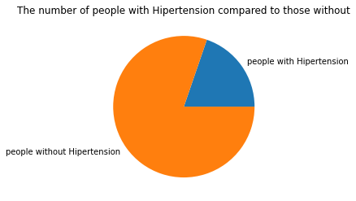

```python
Zz= np.array([Z1,Z2])
mylabels= ["people with Hipertension","people without Hipertension"]
plt.pie(Zz, labels= mylabels)
plt.title("The number of people with Hipertension compared to those without")
plt.show()
```

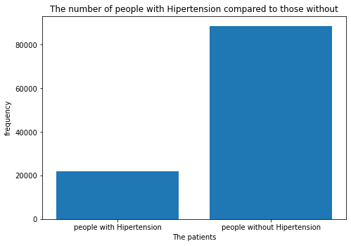

```python
fig= plt.figure()
ax= fig.add_axes([0,0,1,1])
langs=["people with Hipertension","people without Hipertension"]
students=[Z1,Z2]
ax.bar(langs,students)
plt.xlabel("The patients")
plt.ylabel("frequency")
plt.title("The number of people with Hipertension compared to those without")
plt.show()
```

- Diabetes:

```python
from collections import Counter
W= Counter(New['Diabetes'])
print(W)
```

```
Counter({0: 102584, 1: 7943})
```

```python
W1=7943
W2=102584
print("People with diabetes is",W1)
print("People without diabetes is",W2)
```

```
People with diabetes is 7943
People without diabetes is 102584
```

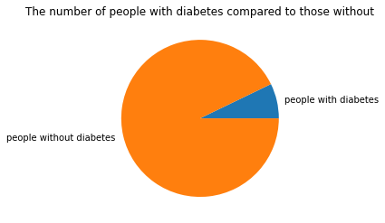

```python
Ww= np.array([W1,W2])
mylabels= ["people with diabetes","people without diabetes"]
plt.pie(Ww, labels= mylabels)
plt.title("The number of people with diabetes compared to those without")
plt.show()
```

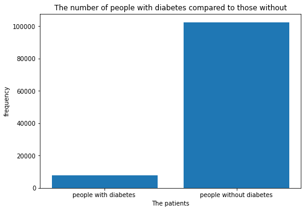

```python
fig= plt.figure()
ax= fig.add_axes([0,0,1,1])
langs=["people with diabetes ","people without diabetes"]
students=[W1,W2]
ax.bar(langs,students)
plt.xlabel("The patients")
plt.ylabel("frequency")
plt.title("The number of people with diabetes compared to those without")
plt.show()
```

Now we can draw conclusions based on the graph, We see that people who are not infected are much more than infected people, so the answer to the question is that the number of appointments was not increased because of diabetes and Hipertension patients, but rather they are one of the categories of patients, and we are also see that people with Hipertension are more than the number of people with diabetes.

And here we will answer the same question as the previous one: is the percentage of alcoholics greater than the patients? Explain it?

```python
from collections import Counter
R= Counter(New['Alcoholism'])
print(R)
```

```
Counter({0: 107167, 1: 3360})
```

```python
R1=3360
R2=107167
print("People with Alcoholism is",R1)
print("People without Alcoholism is",R2)
```

```
People with Alcoholism is 3360
People without Alcoholism is 107167
```

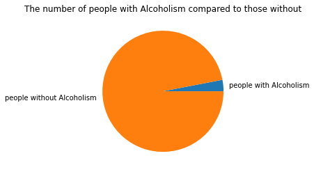

```python
Rr= np.array([R1,R2])
mylabels= ["people with Alcoholism","people without Alcoholism"]
plt.pie(Rr, labels= mylabels)
plt.title("The number of people with Alcoholism compared to those without")

plt.show()
```

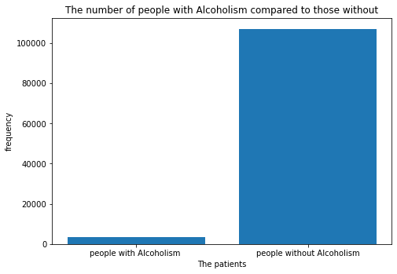

```python
fig= plt.figure()
ax= fig.add_axes([0,0,1,1])
langs=["people with Alcoholism ","people without Alcoholism"]
students=[R1,R2]
ax.bar(langs,students)
plt.xlabel("The patients")
plt.ylabel("frequency")
plt.title("The number of people with Alcoholism compared to those without")
plt.show()
```

We note from the drawing that the percentage of alcoholics is very small, almost unnoticeable, and the reason behind this may be due to more than one reason, as if they are a small group that covers only a little of society and they do not have enough awareness to review their health, etc.

here we will talk about the handicap and we will notice a problem in the data that we will solve in one of the ways and make it clear.

```python
New.loc[(New.Handcap !=0)&(New.Handcap !=1), ]
```

|  | PatientId | Gender | Age | Neighbourhood | Scholarship | Hipertension | Diabetes | Alcoholism | Handcap | SMS_received | No-show |
| --- | --- | --- | --- | --- | --- | --- | --- | --- | --- | --- | --- |
| 946 | 7.282582e+13 | M | 94 | BELA VISTA | 0 | 1 | 1 | 0 | 2 | 1 | No |
| 1665 | 1.242919e+13 | M | 64 | SANTA MARTHA | 0 | 1 | 0 | 1 | 2 | 1 | No |
| 1666 | 1.242919e+13 | M | 64 | SANTA MARTHA | 0 | 1 | 0 | 1 | 2 | 0 | No |
| 2071 | 1.242919e+13 | M | 64 | SANTA MARTHA | 0 | 1 | 0 | 1 | 2 | 0 | No |
| 2091 | 1.491829e+13 | F | 11 | ANDORINHAS | 0 | 0 | 0 | 0 | 2 | 0 | No |
| ... | ... | ... | ... | ... | ... | ... | ... | ... | ... | ... | ... |
| 108376 | 2.387212e+14 | F | 44 | ROMÃO | 0 | 1 | 1 | 0 | 2 | 1 | No |
| 109484 | 3.589495e+14 | M | 64 | DA PENHA | 0 | 1 | 1 | 0 | 2 | 0 | No |
| 109733 | 5.662976e+14 | F | 34 | JUCUTUQUARA | 0 | 0 | 0 | 0 | 2 | 1 | No |
| 109975 | 4.522185e+13 | M | 39 | PRAIA DO SUÁ | 1 | 0 | 0 | 0 | 2 | 1 | No |
| 110107 | 7.143714e+14 | F | 44 | RESISTÊNCIA | 0 | 0 | 0 | 0 | 2 | 1 | No |

199 rows × 11 columns

```python
New.loc[(New.Handcap !=0)&(New.Handcap !=1),['Handcap']]=1
```

```python
from collections import Counter
T= Counter(New['Handcap'])
print(T)
```

```
Counter({0: 108286, 1: 2241})
```

```python
T1=2241
T2=108285
print("People with Handcap is",T1)
print("People without Handcap is",T2)
```

```
People with Handcap is 2241
People without Handcap is 108285
```

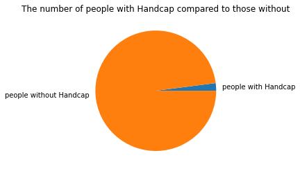

```python
Tt= np.array([T1,T2])
mylabels= ["people with Handcap","people without Handcap"]
plt.pie(Tt, labels= mylabels)
plt.title("The number of people with Handcap compared to those without")

plt.show()
```

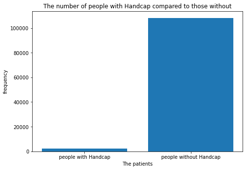

```python
fig= plt.figure()
ax= fig.add_axes([0,0,1,1])
langs=["people with Handcap","people without Handcap"]
students=[T1,T2]
ax.bar(langs,students)
plt.xlabel("The patients")
plt.ylabel("frequency")
plt.title("The number of people with Handcap compared to those without")
plt.show()
```

We note that people with handcap represent a very small percentage compared to the general Patients.

part two:

We will see the sex data. Are males more than females in booking appointments? Or vice versa.. Then we will see who is more committed to attend appointments, males or females?

```python
from collections import Counter
MF= Counter(New['Gender'])
print(MF)
```

```
Counter({'F': 71840, 'M': 38687})
```

```python
F=71840
M=38687
print("The number of females is",F)
print("The number of males is",M)
```

```
The number of females is 71840
The number of males is 38687
```

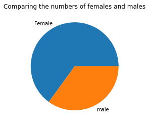

```python
Q= np.array([F,M])
mylabels= ["Female","male"]
plt.pie(Q, labels= mylabels)
plt.title("Comparing the numbers of females and males")
plt.show()
```

Here we clearly see that females are more than half of the total number, meaning that females are more than males.

So let's see who are the most committed..

```python
New.groupby(["Gender","No-show"]).count()
```

| Gender | No-show | PatientId | Age | Neighbourhood | Scholarship | Hipertension | Diabetes | Alcoholism | Handcap | SMS_received |
| --- | --- | --- | --- | --- | --- | --- | --- | --- | --- | --- |
| F | No | 57246 | 57246 | 57246 | 57246 | 57246 | 57246 | 57246 | 57246 | 57246 |
|  | Yes | 14594 | 14594 | 14594 | 14594 | 14594 | 14594 | 14594 | 14594 | 14594 |
| M | No | 30962 | 30962 | 30962 | 30962 | 30962 | 30962 | 30962 | 30962 | 30962 |
|  | Yes | 7725 | 7725 | 7725 | 7725 | 7725 | 7725 | 7725 | 7725 | 7725 |

```python
FN= 57246
FY= 14594
MN= 30962
MY= 7725
Total= (FN+FY+MN+MY)
print("The number of females who attended the appointment is",FN)
print("The number of females who not attended the appointment is",FY)
print("The number of males who attended the appointment is",MN)
print("The number of males who not attended the appointment is",MY)
print("total number is",Total)
```

```
The number of females who attended the appointment is 57246
The number of females who not attended the appointment is 14594
The number of males who attended the appointment is 30962
The number of males who not attended the appointment is 7725
total number is 110527
```

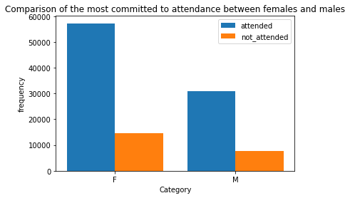

```python
X=['F','M']
Yattended= [57246,30962]
Znotattended= [14594,7725]
X_axis= np.arange(len(X))
plt.bar(X_axis-0.2,Yattended, 0.4, label='attended')
plt.bar(X_axis+0.2,Znotattended, 0.4, label='not_attended')
plt.xticks(X_axis, X)
plt.xlabel("Category")
plt.ylabel("frequency")
plt.title("Comparison of the most committed to attendance between females and males")
plt.legend()
plt.show()
```

Comparing to the previous chart can be difficult, so let's try another chart..

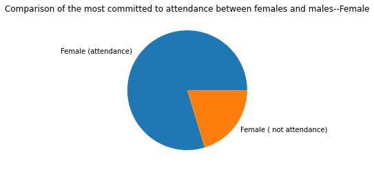

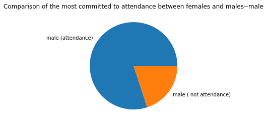

```python
U= np.array([FN,FY])
mylabels= ["Female (attendance) ","Female ( not attendance)"]
plt.pie(U, labels= mylabels)
plt.title("Comparison of the most committed to attendance between females and males--Female")

plt.show()
V= np.array([MN,MY])
mylabels= ["male (attendance) ","male ( not attendance)"]
plt.pie(V, labels= mylabels)
plt.title("Comparison of the most committed to attendance between females and males--male")
plt.show()
```

We note that there is no difference in the amount of commitment for both males and females, so they are equal in commitment. Greatl!!

the third part:

And here we will see the percentage of those who attended the appointment and those who did not attend in general..

```python
from collections import Counter
NY= Counter(New['No-show'])
print(NY)
```

```
Counter({'No': 88208, 'Yes': 22319})
```

```python
NO= (88208/110527)*100
YES= (22319/110527)*100
print("The percentage of attendance at appointments is",NO,"%")
print("The percentage of not attendance at appointments is",YES,"%")
```

```
The percentage of attendance at appointments is 79.8067440534892 %
The percentage of not attendance at appointments is 20.193255946510806 %
```

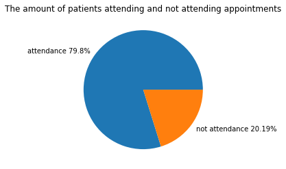

```python
A= np.array([NO,YES])
mylabels= ["attendance 79.8%","not attendance 20.19%"]
plt.pie(A, labels= mylabels)
plt.title("The amount of patients attending and not attending appointments")
plt.show()
```

We see that the percentage of people who attended the appointment is four times more than those who did not attend.

part Four:

We will compare neighborhoods to find out what are neighborhoods patients live in and come from.

- This may benefit us in providing health centers in the areas where there is a lot of housing in order to facilitate the patients-

```python
from collections import Counter
L= Counter(New['Neighbourhood'])
print(L)
```

```
Counter({'JARDIM CAMBURI': 7717, 'MARIA ORTIZ': 5805, 'RESISTÊNCIA': 4431, 'JARDIM DA PENHA': 3877, 'ITARARÉ': 3514, 'CENTRO': 3334, 'TABUAZEIRO': 3132, 'SANTA MARTHA': 3131, 'JESUS DE NAZARETH': 2853, 'BONFIM': 2773, 'SANTO ANTÔNIO': 2746, 'SANTO ANDRÉ': 2571, 'CARATOÍRA': 2565, 'JABOUR': 2509, 'SÃ…
```

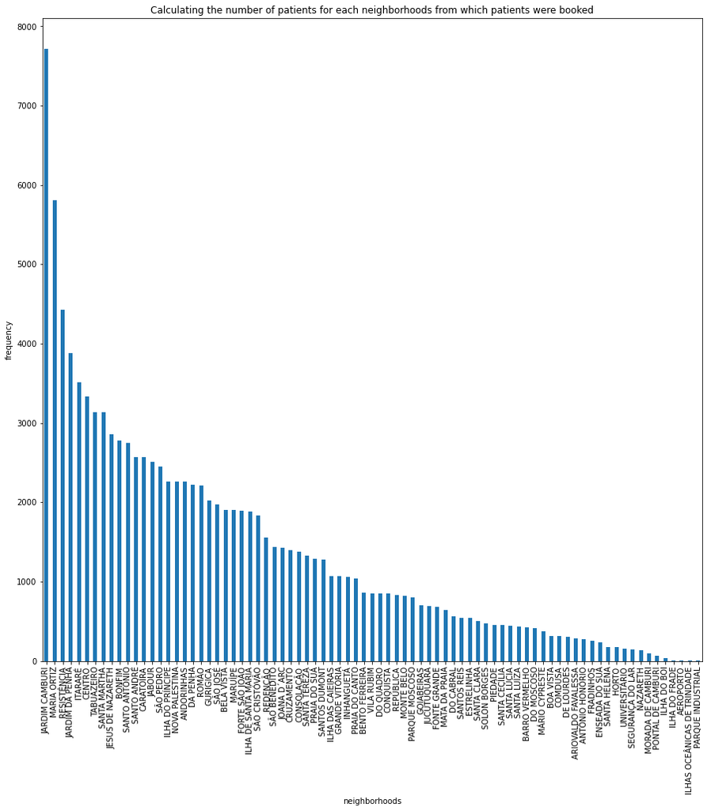

```python
Patients['Neighbourhood'].value_counts().plot(kind='bar',figsize=(15,15));
plt.xlabel("neighborhoods")
plt.ylabel("frequency")
plt.title("Calculating the number of patients for each neighborhoods from which patients were booked")
```

We see the five neighborhoods that ranked first in the number of reservations Patients came from: 1- JARDIM CAMBURI 2- MARIA ORTIZ 3- RESISTÊNCIA 4- JARDIM DA PENHA 5- ITARARÉ

Part V:

In this section, we will analyze age-related data.

```python
 New['Age'].describe()
```

```
count    110527.000000
mean         37.088874
std          23.110205
min          -1.000000
25%          18.000000
50%          37.000000
75%          55.000000
max         115.000000
Name: Age, dtype: float64
```

```python
Avg= 37.088874
print("average age is",Avg)
```

```
average age is 37.088874
```

After we know the average and some statistics, we will graph the age groups..

```python
New.groupby(["Age","No-show"]).count()
```

| Age | No-show | PatientId | Gender | Neighbourhood | Scholarship | Hipertension | Diabetes | Alcoholism | Handcap | SMS_received |
| --- | --- | --- | --- | --- | --- | --- | --- | --- | --- | --- |
| -1 | No | 1 | 1 | 1 | 1 | 1 | 1 | 1 | 1 | 1 |
| 0 | No | 2900 | 2900 | 2900 | 2900 | 2900 | 2900 | 2900 | 2900 | 2900 |
|  | Yes | 639 | 639 | 639 | 639 | 639 | 639 | 639 | 639 | 639 |
| 1 | No | 1858 | 1858 | 1858 | 1858 | 1858 | 1858 | 1858 | 1858 | 1858 |
|  | Yes | 415 | 415 | 415 | 415 | 415 | 415 | 415 | 415 | 415 |
| ... | ... | ... | ... | ... | ... | ... | ... | ... | ... | ... |
| 99 | No | 1 | 1 | 1 | 1 | 1 | 1 | 1 | 1 | 1 |
| 100 | No | 4 | 4 | 4 | 4 | 4 | 4 | 4 | 4 | 4 |
| 102 | No | 2 | 2 | 2 | 2 | 2 | 2 | 2 | 2 | 2 |
| 115 | No | 2 | 2 | 2 | 2 | 2 | 2 | 2 | 2 | 2 |
|  | Yes | 3 | 3 | 3 | 3 | 3 | 3 | 3 | 3 | 3 |

204 rows × 9 columns

Now we see a noticeable problem, which is the presence of incorrect data, i.e. an error in the entry, which is the value (-1).

So we will delete the row containing the value (-1) to get rid of this problem.

```python
minus_one=New.loc[New.Age==-1]
New.drop(New.loc[New.Age==-1].index,axis=0,errors='ignore',inplace=True)
```

```python
New.describe()
```

|  | PatientId | Age | Scholarship | Hipertension | Diabetes | Alcoholism | Handcap | SMS_received |
| --- | --- | --- | --- | --- | --- | --- | --- | --- |
| count | 1.105260e+05 | 110526.000000 | 110526.000000 | 110526.000000 | 110526.000000 | 110526.000000 | 110526.000000 | 110526.000000 |
| mean | 1.474934e+14 | 37.089219 | 0.098266 | 0.197248 | 0.071865 | 0.030400 | 0.020276 | 0.321029 |
| std | 2.560943e+14 | 23.110026 | 0.297676 | 0.397923 | 0.258266 | 0.171686 | 0.140943 | 0.466874 |
| min | 3.921784e+04 | 0.000000 | 0.000000 | 0.000000 | 0.000000 | 0.000000 | 0.000000 | 0.000000 |
| 25% | 4.172536e+12 | 18.000000 | 0.000000 | 0.000000 | 0.000000 | 0.000000 | 0.000000 | 0.000000 |
| 50% | 3.173184e+13 | 37.000000 | 0.000000 | 0.000000 | 0.000000 | 0.000000 | 0.000000 | 0.000000 |
| 75% | 9.438963e+13 | 55.000000 | 0.000000 | 0.000000 | 0.000000 | 0.000000 | 0.000000 | 1.000000 |
| max | 9.999816e+14 | 115.000000 | 1.000000 | 1.000000 | 1.000000 | 1.000000 | 1.000000 | 1.000000 |

After we have solved the problem, we will draw a histogram for the age groups to show the most age groups to book appointments..

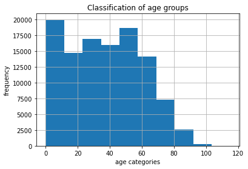

```python
New['Age'].hist()
plt.xlabel("age categories")
plt.ylabel("frequency")
plt.title("Classification of age groups")
```

The age groups most booked appointments are: 1- From 0 to 10 approx 2- From 47 to 57 approx 3- From 23 to 35 approx

Sixth part:

```python
New.groupby(["SMS_received","No-show"]).count()
```

| SMS_received | No-show | PatientId | Gender | Age | Neighbourhood | Scholarship | Hipertension | Diabetes | Alcoholism | Handcap |
| --- | --- | --- | --- | --- | --- | --- | --- | --- | --- | --- |
| 0 | No | 62509 | 62509 | 62509 | 62509 | 62509 | 62509 | 62509 | 62509 | 62509 |
|  | Yes | 12535 | 12535 | 12535 | 12535 | 12535 | 12535 | 12535 | 12535 | 12535 |
| 1 | No | 25698 | 25698 | 25698 | 25698 | 25698 | 25698 | 25698 | 25698 | 25698 |
|  | Yes | 9784 | 9784 | 9784 | 9784 | 9784 | 9784 | 9784 | 9784 | 9784 |

```python
Y1=62510
N1=12535
Y2=25698
N2=9784
print('Come to the appointment and send him one message(',Y1,')')
print('He did not show up for the appointment and sent him one message(',N1,')')
print('Come to the appointment and send him more than one message(',Y2,')')
print('He didn ot show up for the appointment and sent him more than one message(',N2,')')
```

[output not shown]

[figure not shown]

```python
I=['one message','more than one message']
Yattended= [62510,25698]
Znotattended= [12535,9784]
I_axis= np.arange(len(I))
plt.bar(I_axis-0.2,Yattended, 0.4, label='attended')
plt.bar(I_axis+0.2,Znotattended, 0.4, label='not_attended')
plt.xticks(I_axis, I)
plt.xlabel("number of messages")
plt.ylabel("frequency")
plt.title("Evaluation the effect of the number of messages on the amount of commitment to attend")
plt.legend()
plt.show()
```

Another graph..

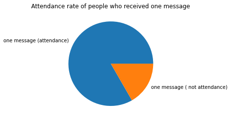

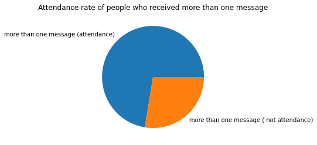

```python
O= np.array([Y1,N1])
mylabels= ["one message (attendance) ","one message ( not attendance)"]
plt.pie(O, labels= mylabels)
plt.title("Attendance rate of people who received one message")
plt.show()
J= np.array([Y2,N2])
mylabels= ["more than one message (attendance) ","more than one message ( not attendance)"]
plt.pie(J, labels= mylabels)
plt.title("Attendance rate of people who received more than one message")

plt.show()
```

Seventh part:

Here we will answer the first question, which is what are the important factors for patients to attend appointments, and from here we can summarize all the previous analyzes at this point.

The columns in the table are: PatientId  
AppointmentID  
Gender  
ScheduledDay  
AppointmentDay  
Age Neighbourhood  
Scholarship Hipertension  
Diabetes  
Alcoholism  
Handcap SMS_received  
No-show

What will be the role of each column in patients adherence to appointments?? Some columns may be useless in patients' commitment to appointments..

2- Neighbourhood Neighborhoods may affect patients’ commitment to appointments so that when the neighborhood is close to the health center, this makes it easier for the patient to reach quickly and vice versa, and like what we mentioned may be a reason for commitment and lack of commitment and not always.

3- Hipertension and Diabetes People with chronic diseases such as diabetes and high blood pressure, their attendance at health centers is important, as it cannot be neglected appointments because this will affect their health negatively.

```
                                              ..THE END..
```